# Week 11 Weekend Homework | Logistic Regression

```
## [1] "C:/Users/colin/Documents/CodeClan/codeclan_homework_ColinS/week_11/weekend_homework"
```

## Read the Data

```r
juice <- read_csv(here("data/orange_juice.csv")) %>% clean_names()
# head(juice)
# str(juice)
# dim(juice)
```

Set up the test-train split. There are 1070 observations, so an 80/20 split would provide around 800 rows for training and 200 for testing;

```r
test_index <- sample(1:nrow(juice), size = nrow(juice)*0.2) # random 20% to be used for test

juice_test  <- slice(juice, test_index)   # create test set
juice_train <- slice(juice, -test_index)  # create training set
```

## Tidy the Data for Logistic Regression

It looks like there are several connections between various columns;

- `store7`, `store_id` and `store` look like they could be connected
- Several price columns look like they are linked

```r
alias(lm(store ~ ., data = juice_train))
```

```
## Model :
## store ~ purchase + weekof_purchase + store_id + price_ch + price_mm +
##     disc_ch + disc_mm + special_ch + special_mm + loyal_ch +
##     sale_price_mm + sale_price_ch + price_diff + store7 + pct_disc_mm +
##     pct_disc_ch + list_price_diff
##
## Complete :
##                 (Intercept) purchaseMM weekof_purchase store_id price_ch
## sale_price_mm    0           0          0               0        0
## sale_price_ch    0           0          0               0        1
## price_diff       0           0          0               0       -1
## list_price_diff  0           0          0               0       -1
##                 price_mm disc_ch disc_mm special_ch special_mm loyal_ch
## sale_price_mm    1        0      -1       0          0          0
## sale_price_ch    0       -1       0       0          0          0
## price_diff       1        1      -1       0          0          0
## list_price_diff  1        0       0       0          0          0
##                 store7Yes pct_disc_mm pct_disc_ch
## sale_price_mm    0         0           0
## sale_price_ch    0         0           0
## price_diff       0         0           0
## list_price_diff  0         0           0
```

The `alias` function shows the following;

- sale_price_mm = price_mm - disc_mm
- sale_price_ch = price_ch - disc_ch
- price_diff = price_mm - price_ch + disc_ch - disc_mm
- list_price_diff = price_mm - price_ch

In addition, it looks like `store`, `store7` and `store_id` are also connected;

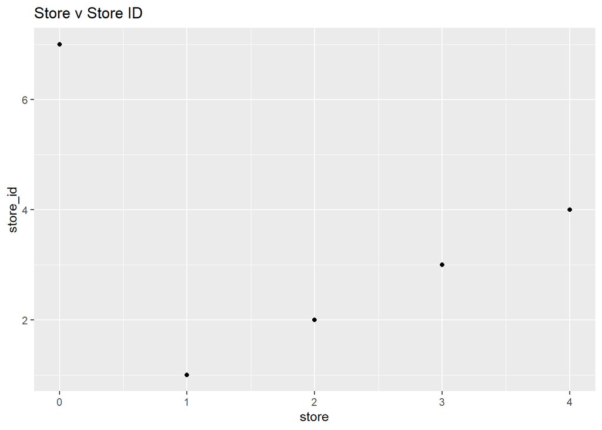

```r
juice_train %>%
  ggplot() +
  aes(x = store, y = store_id) +
  geom_point() +
  labs(title = "Store v Store ID")
```

This plot clearly shows that `store` and `store_id` are connected;

- Store 0 = Store ID 7
- Store 1 = Store ID 1
- Store 2 = Store ID 2
- Store 3 = Store ID 3
- Store 4 = Store ID 4

So in summary, the following columns can safely be removed;

sale_price_mm, sale_price_ch, price_diff, list_price_diff, store_id, store7

### Tidy Up

The `purchase` column may be difficult to run in logistic regression and will be set as a logical answer to the question “did the customer buy Minute Maid?”

```r
juice_train_trim <- juice_train %>%
  mutate(purchase = if_else(purchase == "MM", as.logical(TRUE), as.logical(FALSE))) %>%
  select(-c(sale_price_mm,
            sale_price_ch,
            price_diff,
            list_price_diff,
            store_id,
            store7))
```

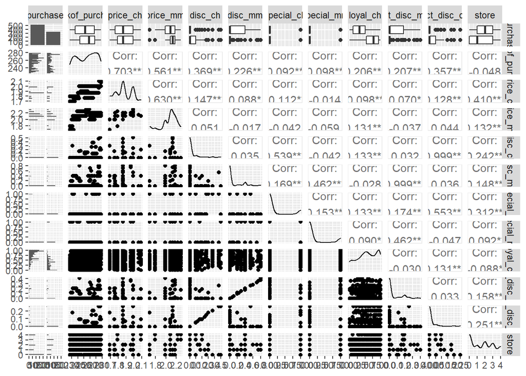

```r
ggpairs(juice_train_trim)
```

Looking at the ggpairs, it seems like the customer brand loyalty score for Citrus Hill is by far the biggest factor in deciding if any customer bought Minute Maid;

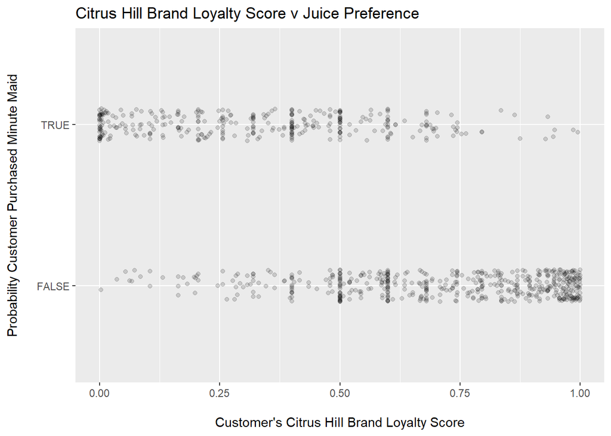

```r
juice_train_trim %>%
  ggplot() +
  aes(x = loyal_ch, y = purchase) +
  geom_jitter(position = position_jitter(h = 0.1), alpha = 0.15) +
  labs(title = "Citrus Hill Brand Loyalty Score v Juice Preference",
       y = "Probability Customer Purchased Minute Maid\n",
       x = "\nCustomer's Citrus Hill Brand Loyalty Score")
```

This plot confirms that customers with higher Citrus Hill brand loyalty scores will usually choose to buy Citrus Hill over Minute Maid.

Applying brand loyalty score `loyal_ch` as a first predictor, the first attempt at creating a model can be started;

#### First Predictor

###### mod1a

```r
juice_1a <- glm(purchase ~ loyal_ch, data = juice_train_trim,
                family = binomial(link = "logit"))

juice_1a
```

```
##
## Call:  glm(formula = purchase ~ loyal_ch, family = binomial(link = "logit"),
##     data = juice_train_trim)
##
## Coefficients:
## (Intercept)     loyal_ch
##       2.621       -5.759
##
## Degrees of Freedom: 855 Total (i.e. Null);  854 Residual
## Null Deviance:       1150
## Residual Deviance: 773.6     AIC: 777.6
```

Plotting this as a function of `purchase` gives the following;

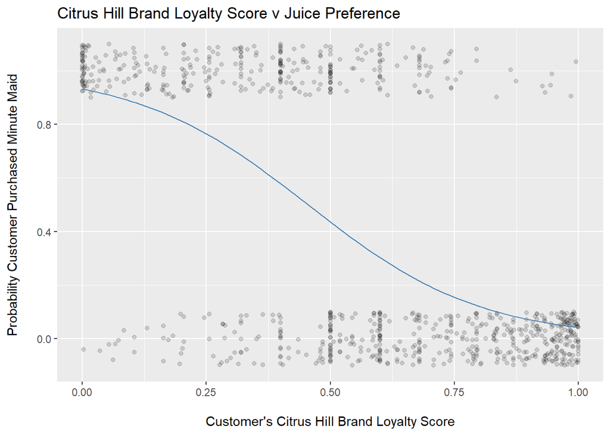

```r
predict_1a <- tibble(loyal_ch = seq(0, 1, 0.01)) %>%
  add_predictions(juice_1a, type = "response")

juice_train_trim %>%
ggplot() +
  aes(x = loyal_ch, y = as.integer(purchase)) +
  geom_jitter(position = position_jitter(h = 0.1), alpha = 0.15) +
  geom_line(data = predict_1a,
            aes(x = loyal_ch, y = pred),
            colour = "steelblue") +
  labs(title = "Citrus Hill Brand Loyalty Score v Juice Preference",
       y = "Probability Customer Purchased Minute Maid\n",
       x = "\nCustomer's Citrus Hill Brand Loyalty Score")
```

The calculations above suggest that if a customer’s Citrus Hill brand loyalty score increases by one unit, then the log of the odds of purchasing a Minute Maid decreases by around 6 units.

Check what the train data looks like with predictions;

```r
juice_1a_with_pred <- juice_train_trim %>%
  add_predictions(juice_1a, type = "response")
head(juice_1a_with_pred)
```

| purchase | weekof_purchase | price_ch | price_mm | disc_ch | disc_mm | special_ch | special_mm | loyal_ch | pct_disc_mm | pct_disc_ch | store | pred |
| --- | --- | --- | --- | --- | --- | --- | --- | --- | --- | --- | --- | --- |
| FALSE | 237 | 1.75 | 1.99 | 0.00 | 0.0 | 0 | 0 | 0.500000 | 0.000000 | 0.000000 | 1 | 0.43563013 |
| FALSE | 239 | 1.75 | 1.99 | 0.00 | 0.3 | 0 | 1 | 0.600000 | 0.150754 | 0.000000 | 1 | 0.30262180 |
| FALSE | 245 | 1.86 | 2.09 | 0.17 | 0.0 | 0 | 0 | 0.680000 | 0.000000 | 0.091398 | 1 | 0.21490878 |
| TRUE | 227 | 1.69 | 1.69 | 0.00 | 0.0 | 0 | 0 | 0.400000 | 0.000000 | 0.000000 | 1 | 0.57859577 |
| FALSE | 230 | 1.69 | 1.99 | 0.00 | 0.0 | 0 | 1 | 0.965228 | 0.000000 | 0.000000 | 0 | 0.05029272 |
| FALSE | 232 | 1.69 | 1.99 | 0.00 | 0.4 | 1 | 1 | 0.972182 | 0.201005 | 0.000000 | 0 | 0.04841388 |

```r
summary(juice_1a)
```

```
##
## Call:
## glm(formula = purchase ~ loyal_ch, family = binomial(link = "logit"),
##     data = juice_train_trim)
##
## Deviance Residuals:
##     Min       1Q   Median       3Q      Max
## -2.3142  -0.6956  -0.3211   0.6663   2.5112
##
## Coefficients:
##             Estimate Std. Error z value Pr(>|z|)
## (Intercept)   2.6207     0.2156   12.16   <2e-16 ***
## loyal_ch     -5.7593     0.3870  -14.88   <2e-16 ***
## ---
## Signif. codes:  0 '***' 0.001 '**' 0.01 '*' 0.05 '.' 0.1 ' ' 1
##
## (Dispersion parameter for binomial family taken to be 1)
##
##     Null deviance: 1150.22  on 855  degrees of freedom
## Residual deviance:  773.56  on 854  degrees of freedom
## AIC: 777.56
##
## Number of Fisher Scoring iterations: 5
```

The problem with trying to make predictions at this stage is that there is currently no threshold set to define at what probability a customer would choose Minute Maid over Citrus Hill. Try 0.5;

```r
threshold <- 0.5

juice_1a_with_pred <- juice_1a_with_pred %>%
  mutate(pred_thresh_0.5 = pred >= threshold) %>%
  relocate(pred_thresh_0.5, .after = "purchase")

head(juice_1a_with_pred, 10)
```

| purchase | pred_thresh_0.5 | weekof_purchase | price_ch | price_mm | disc_ch | disc_mm | special_ch | special_mm | loyal_ch | pct_disc_mm | pct_disc_ch | store | pred |
| --- | --- | --- | --- | --- | --- | --- | --- | --- | --- | --- | --- | --- | --- |
| FALSE | FALSE | 237 | 1.75 | 1.99 | 0.00 | 0.0 | 0 | 0 | 0.500000 | 0.000000 | 0.000000 | 1 | 0.43563013 |
| FALSE | FALSE | 239 | 1.75 | 1.99 | 0.00 | 0.3 | 0 | 1 | 0.600000 | 0.150754 | 0.000000 | 1 | 0.30262180 |
| FALSE | FALSE | 245 | 1.86 | 2.09 | 0.17 | 0.0 | 0 | 0 | 0.680000 | 0.000000 | 0.091398 | 1 | 0.21490878 |
| TRUE | TRUE | 227 | 1.69 | 1.69 | 0.00 | 0.0 | 0 | 0 | 0.400000 | 0.000000 | 0.000000 | 1 | 0.57859577 |
| FALSE | FALSE | 230 | 1.69 | 1.99 | 0.00 | 0.0 | 0 | 1 | 0.965228 | 0.000000 | 0.000000 | 0 | 0.05029272 |
| FALSE | FALSE | 232 | 1.69 | 1.99 | 0.00 | 0.4 | 1 | 1 | 0.972182 | 0.201005 | 0.000000 | 0 | 0.04841388 |
| FALSE | FALSE | 234 | 1.75 | 1.99 | 0.00 | 0.4 | 1 | 0 | 0.977746 | 0.201005 | 0.000000 | 0 | 0.04695877 |
| FALSE | FALSE | 238 | 1.75 | 1.99 | 0.00 | 0.4 | 0 | 0 | 0.985757 | 0.201005 | 0.000000 | 0 | 0.04493657 |
| FALSE | FALSE | 278 | 2.06 | 2.13 | 0.00 | 0.0 | 0 | 0 | 0.795200 | 0.000000 | 0.000000 | 0 | 0.12356935 |
| TRUE | FALSE | 240 | 1.75 | 1.99 | 0.00 | 0.3 | 0 | 1 | 0.500000 | 0.150754 | 0.000000 | 1 | 0.43563013 |

The performance of the model can be checked with a confusion table;

```r
conf_table <- juice_1a_with_pred %>%
  tabyl(purchase, pred_thresh_0.5)

conf_table
```

| purchase | FALSE | TRUE |
| --- | --- | --- |
| FALSE | 445 | 71 |
| TRUE | 107 | 233 |

```r
juice_1a_with_pred %>%
  accuracy(as.factor(purchase), as.factor(pred_thresh_0.5))
```

| .metric | .estimator | .estimate |
| --- | --- | --- |
| accuracy | binary | 0.7920561 |

Does this improve with a higher threshold? Can’t think why it would in this case where we only have a choice between one of two drinks, but try 0.6;

```r
threshold <- 0.6

juice_1a_with_pred <- juice_1a_with_pred %>%
  mutate(pred_thresh_0.6 = pred >= threshold) %>%
  relocate(pred_thresh_0.6, .after = "purchase")

head(juice_1a_with_pred, 10)
```

| purchase | pred_thresh_0.6 | pred_thresh_0.5 | weekof_purchase | price_ch | price_mm | disc_ch | disc_mm | special_ch | special_mm | loyal_ch | pct_disc_mm | pct_disc_ch | store | pred |
| --- | --- | --- | --- | --- | --- | --- | --- | --- | --- | --- | --- | --- | --- | --- |
| FALSE | FALSE | FALSE | 237 | 1.75 | 1.99 | 0.00 | 0.0 | 0 | 0 | 0.500000 | 0.000000 | 0.000000 | 1 | 0.43563013 |
| FALSE | FALSE | FALSE | 239 | 1.75 | 1.99 | 0.00 | 0.3 | 0 | 1 | 0.600000 | 0.150754 | 0.000000 | 1 | 0.30262180 |
| FALSE | FALSE | FALSE | 245 | 1.86 | 2.09 | 0.17 | 0.0 | 0 | 0 | 0.680000 | 0.000000 | 0.091398 | 1 | 0.21490878 |
| TRUE | FALSE | TRUE | 227 | 1.69 | 1.69 | 0.00 | 0.0 | 0 | 0 | 0.400000 | 0.000000 | 0.000000 | 1 | 0.57859577 |
| FALSE | FALSE | FALSE | 230 | 1.69 | 1.99 | 0.00 | 0.0 | 0 | 1 | 0.965228 | 0.000000 | 0.000000 | 0 | 0.05029272 |
| FALSE | FALSE | FALSE | 232 | 1.69 | 1.99 | 0.00 | 0.4 | 1 | 1 | 0.972182 | 0.201005 | 0.000000 | 0 | 0.04841388 |
| FALSE | FALSE | FALSE | 234 | 1.75 | 1.99 | 0.00 | 0.4 | 1 | 0 | 0.977746 | 0.201005 | 0.000000 | 0 | 0.04695877 |
| FALSE | FALSE | FALSE | 238 | 1.75 | 1.99 | 0.00 | 0.4 | 0 | 0 | 0.985757 | 0.201005 | 0.000000 | 0 | 0.04493657 |
| FALSE | FALSE | FALSE | 278 | 2.06 | 2.13 | 0.00 | 0.0 | 0 | 0 | 0.795200 | 0.000000 | 0.000000 | 0 | 0.12356935 |
| TRUE | FALSE | FALSE | 240 | 1.75 | 1.99 | 0.00 | 0.3 | 0 | 1 | 0.500000 | 0.150754 | 0.000000 | 1 | 0.43563013 |

The performance of the model can be checked with a confusion table;

```r
conf_table <- juice_1a_with_pred %>%
  tabyl(purchase, pred_thresh_0.6)

conf_table
```

| purchase | FALSE | TRUE |
| --- | --- | --- |
| FALSE | 466 | 50 |
| TRUE | 152 | 188 |

```r
juice_1a_with_pred %>%
  accuracy(as.factor(purchase), as.factor(pred_thresh_0.6))
```

| .metric | .estimator | .estimate |
| --- | --- | --- |
| accuracy | binary | 0.7640187 |

Reset threshold back to 0.5;

```r
threshold <- 0.5
```

#### Second Predictor

###### mod2a

```r
juice_second <- glm(purchase ~ ., data = juice_train_trim,
                family = binomial(link = "logit"))

summary(juice_second)
```

```
##
## Call:
## glm(formula = purchase ~ ., family = binomial(link = "logit"),
##     data = juice_train_trim)
##
## Deviance Residuals:
##     Min       1Q   Median       3Q      Max
## -2.6744  -0.5869  -0.2578   0.5601   2.6862
##
## Coefficients:
##                   Estimate Std. Error z value Pr(>|z|)
## (Intercept)       6.038508   2.194531   2.752  0.00593 **
## weekof_purchase  -0.002334   0.011099  -0.210  0.83343
## price_ch          2.764350   1.841058   1.502  0.13323
## price_mm         -3.971062   0.978756  -4.057 4.97e-05 ***
## disc_ch           3.741296  19.196092   0.195  0.84547
## disc_mm          28.160415  10.080476   2.794  0.00521 **
## special_ch       -0.070809   0.360219  -0.197  0.84416
## special_mm        0.461968   0.294811   1.567  0.11712
## loyal_ch         -5.996594   0.422855 -14.181  < 2e-16 ***
## pct_disc_mm     -54.097906  21.041202  -2.571  0.01014 *
## pct_disc_ch     -13.877475  36.274773  -0.383  0.70204
## store             0.118852   0.091028   1.306  0.19167
## ---
## Signif. codes:  0 '***' 0.001 '**' 0.01 '*' 0.05 '.' 0.1 ' ' 1
##
## (Dispersion parameter for binomial family taken to be 1)
##
##     Null deviance: 1150.22  on 855  degrees of freedom
## Residual deviance:  688.73  on 844  degrees of freedom
## AIC: 712.73
##
## Number of Fisher Scoring iterations: 5
```

It looks like `price_mm` is a likely candidate for the next predictor;

*I misread the summary table first time round and took `price_ch` by mistake -* *it wasn’t until I looked at my results that I realised my error! Have left the* *code in but commented it out…*

```r
# juice_2a <- glm(purchase ~ loyal_ch + price_ch, data = juice_train_trim,
#                 family = binomial(link = "logit"))
#
# juice_2a
```

```r
# tidy_out <- tidy(juice_2a)
# tidy_out
```

###### mod2b

It would seem sensible that if a lower price was offered on Minute Maid then the probability might go up that more people would choose this drink.

```r
juice_2b <- glm(purchase ~ loyal_ch + price_mm, data = juice_train_trim,
                family = binomial(link = "logit"))

summary(juice_2b)
```

```
##
## Call:
## glm(formula = purchase ~ loyal_ch + price_mm, family = binomial(link = "logit"),
##     data = juice_train_trim)
##
## Deviance Residuals:
##     Min       1Q   Median       3Q      Max
## -2.4100  -0.6699  -0.3185   0.6662   2.5481
##
## Coefficients:
##             Estimate Std. Error z value Pr(>|z|)
## (Intercept)   6.2605     1.3359   4.686 2.78e-06 ***
## loyal_ch     -5.6821     0.3867 -14.693  < 2e-16 ***
## price_mm     -1.7740     0.6372  -2.784  0.00537 **
## ---
## Signif. codes:  0 '***' 0.001 '**' 0.01 '*' 0.05 '.' 0.1 ' ' 1
##
## (Dispersion parameter for binomial family taken to be 1)
##
##     Null deviance: 1150.22  on 855  degrees of freedom
## Residual deviance:  765.62  on 853  degrees of freedom
## AIC: 771.62
##
## Number of Fisher Scoring iterations: 5
```

Including `price_mm` returns an AIC marginally lower than `loyal_ch` on it’s own, suggesting it might create a better fitting model.

```r
tidy_out <- tidy(juice_2b)
tidy_out
```

| term | estimate | std.error | statistic | p.value |
| --- | --- | --- | --- | --- |
| (Intercept) | 6.260465 | 1.3358781 | 4.686404 | 2.780469e-06 |
| loyal_ch | -5.682113 | 0.3867128 | -14.693370 | 7.108904e-49 |
| price_mm | -1.774035 | 0.6372127 | -2.784055 | 5.368400e-03 |

So the model so far is;

$$purchase \sim loyal\_ch + price\_mm$$

```r
juice_2b_with_pred <- juice_train_trim %>%
  add_predictions(juice_2b, type = "response")
head(juice_2b_with_pred)
```

| purchase | weekof_purchase | price_ch | price_mm | disc_ch | disc_mm | special_ch | special_mm | loyal_ch | pct_disc_mm | pct_disc_ch | store | pred |
| --- | --- | --- | --- | --- | --- | --- | --- | --- | --- | --- | --- | --- |
| FALSE | 237 | 1.75 | 1.99 | 0.00 | 0.0 | 0 | 0 | 0.500000 | 0.000000 | 0.000000 | 1 | 0.47229805 |
| FALSE | 239 | 1.75 | 1.99 | 0.00 | 0.3 | 0 | 1 | 0.600000 | 0.150754 | 0.000000 | 1 | 0.33645490 |
| FALSE | 245 | 1.86 | 2.09 | 0.17 | 0.0 | 0 | 0 | 0.680000 | 0.000000 | 0.091398 | 1 | 0.21230195 |
| TRUE | 227 | 1.69 | 1.69 | 0.00 | 0.0 | 0 | 0 | 0.400000 | 0.000000 | 0.000000 | 1 | 0.72898924 |
| FALSE | 230 | 1.69 | 1.99 | 0.00 | 0.0 | 0 | 1 | 0.965228 | 0.000000 | 0.000000 | 0 | 0.05983866 |
| FALSE | 232 | 1.69 | 1.99 | 0.00 | 0.4 | 1 | 1 | 0.972182 | 0.201005 | 0.000000 | 0 | 0.05765399 |

```r
summary(juice_2b)
```

```
##
## Call:
## glm(formula = purchase ~ loyal_ch + price_mm, family = binomial(link = "logit"),
##     data = juice_train_trim)
##
## Deviance Residuals:
##     Min       1Q   Median       3Q      Max
## -2.4100  -0.6699  -0.3185   0.6662   2.5481
##
## Coefficients:
##             Estimate Std. Error z value Pr(>|z|)
## (Intercept)   6.2605     1.3359   4.686 2.78e-06 ***
## loyal_ch     -5.6821     0.3867 -14.693  < 2e-16 ***
## price_mm     -1.7740     0.6372  -2.784  0.00537 **
## ---
## Signif. codes:  0 '***' 0.001 '**' 0.01 '*' 0.05 '.' 0.1 ' ' 1
##
## (Dispersion parameter for binomial family taken to be 1)
##
##     Null deviance: 1150.22  on 855  degrees of freedom
## Residual deviance:  765.62  on 853  degrees of freedom
## AIC: 771.62
##
## Number of Fisher Scoring iterations: 5
```

So both `loyal_ch` and `price_mm` are significant and the AIC with two predictors is slightly smaller than with one predictor.

Check predictions again against threshold = 0.5;

```r
threshold <- 0.5

juice_2b_with_pred <- juice_2b_with_pred %>%
  mutate(pred_thresh_0.5 = pred >= threshold) %>%
  relocate(pred_thresh_0.5, .after = "purchase")

head(juice_2b_with_pred, 10)
```

| purchase | pred_thresh_0.5 | weekof_purchase | price_ch | price_mm | disc_ch | disc_mm | special_ch | special_mm | loyal_ch | pct_disc_mm | pct_disc_ch | store | pred |
| --- | --- | --- | --- | --- | --- | --- | --- | --- | --- | --- | --- | --- | --- |
| FALSE | FALSE | 237 | 1.75 | 1.99 | 0.00 | 0.0 | 0 | 0 | 0.500000 | 0.000000 | 0.000000 | 1 | 0.47229805 |
| FALSE | FALSE | 239 | 1.75 | 1.99 | 0.00 | 0.3 | 0 | 1 | 0.600000 | 0.150754 | 0.000000 | 1 | 0.33645490 |
| FALSE | FALSE | 245 | 1.86 | 2.09 | 0.17 | 0.0 | 0 | 0 | 0.680000 | 0.000000 | 0.091398 | 1 | 0.21230195 |
| TRUE | TRUE | 227 | 1.69 | 1.69 | 0.00 | 0.0 | 0 | 0 | 0.400000 | 0.000000 | 0.000000 | 1 | 0.72898924 |
| FALSE | FALSE | 230 | 1.69 | 1.99 | 0.00 | 0.0 | 0 | 1 | 0.965228 | 0.000000 | 0.000000 | 0 | 0.05983866 |
| FALSE | FALSE | 232 | 1.69 | 1.99 | 0.00 | 0.4 | 1 | 1 | 0.972182 | 0.201005 | 0.000000 | 0 | 0.05765399 |
| FALSE | FALSE | 234 | 1.75 | 1.99 | 0.00 | 0.4 | 1 | 0 | 0.977746 | 0.201005 | 0.000000 | 0 | 0.05596016 |
| FALSE | FALSE | 238 | 1.75 | 1.99 | 0.00 | 0.4 | 0 | 0 | 0.985757 | 0.201005 | 0.000000 | 0 | 0.05360348 |
| FALSE | FALSE | 278 | 2.06 | 2.13 | 0.00 | 0.0 | 0 | 0 | 0.795200 | 0.000000 | 0.000000 | 0 | 0.11540869 |
| TRUE | FALSE | 240 | 1.75 | 1.99 | 0.00 | 0.3 | 0 | 1 | 0.500000 | 0.150754 | 0.000000 | 1 | 0.47229805 |

The performance of the model can be checked with a confusion table;

```r
conf_table <- juice_2b_with_pred %>%
  tabyl(purchase, pred_thresh_0.5)

conf_table
```

| purchase | FALSE | TRUE |
| --- | --- | --- |
| FALSE | 442 | 74 |
| TRUE | 108 | 232 |

```r
juice_2b_with_pred %>%
  accuracy(as.factor(purchase), as.factor(pred_thresh_0.5))
```

| .metric | .estimator | .estimate |
| --- | --- | --- |
| accuracy | binary | 0.7873832 |

Again, an accuracy of 80%. The sensitivity (or True Positive Rate) is;

```r
juice_2b_with_pred %>%
  sensitivity(as.factor(purchase), as.factor(pred_thresh_0.5))
```

| .metric | .estimator | .estimate |
| --- | --- | --- |
| sensitivity | binary | 0.8565891 |

The True Positive Rate is 86%, which seems quite good.

And the specificity (True Negative Rate);

```r
juice_2b_with_pred %>%
  specificity(as.factor(purchase), as.factor(pred_thresh_0.5))
```

| .metric | .estimator | .estimate |
| --- | --- | --- |
| specificity | binary | 0.6823529 |

The True Negative Rate is around 70%, which is a little worse than the TPR.

#### Third Predictor

###### mod3a

```r
juice_third <- glm(purchase ~ ., data = juice_train_trim,
                family = binomial(link = "logit"))

summary(juice_third)
```

```
##
## Call:
## glm(formula = purchase ~ ., family = binomial(link = "logit"),
##     data = juice_train_trim)
##
## Deviance Residuals:
##     Min       1Q   Median       3Q      Max
## -2.6744  -0.5869  -0.2578   0.5601   2.6862
##
## Coefficients:
##                   Estimate Std. Error z value Pr(>|z|)
## (Intercept)       6.038508   2.194531   2.752  0.00593 **
## weekof_purchase  -0.002334   0.011099  -0.210  0.83343
## price_ch          2.764350   1.841058   1.502  0.13323
## price_mm         -3.971062   0.978756  -4.057 4.97e-05 ***
## disc_ch           3.741296  19.196092   0.195  0.84547
## disc_mm          28.160415  10.080476   2.794  0.00521 **
## special_ch       -0.070809   0.360219  -0.197  0.84416
## special_mm        0.461968   0.294811   1.567  0.11712
## loyal_ch         -5.996594   0.422855 -14.181  < 2e-16 ***
## pct_disc_mm     -54.097906  21.041202  -2.571  0.01014 *
## pct_disc_ch     -13.877475  36.274773  -0.383  0.70204
## store             0.118852   0.091028   1.306  0.19167
## ---
## Signif. codes:  0 '***' 0.001 '**' 0.01 '*' 0.05 '.' 0.1 ' ' 1
##
## (Dispersion parameter for binomial family taken to be 1)
##
##     Null deviance: 1150.22  on 855  degrees of freedom
## Residual deviance:  688.73  on 844  degrees of freedom
## AIC: 712.73
##
## Number of Fisher Scoring iterations: 5
```

Reviewing the summary above again suggests that `disc_mm` is also a likely predictor for the model;

```r
juice_3a <- glm(purchase ~ loyal_ch + price_mm + disc_mm,
                data = juice_train_trim,
                family = binomial(link = "logit"))

summary(juice_3a)
```

```
##
## Call:
## glm(formula = purchase ~ loyal_ch + price_mm + disc_mm, family = binomial(link = "logit"),
##     data = juice_train_trim)
##
## Deviance Residuals:
##     Min       1Q   Median       3Q      Max
## -2.4649  -0.6447  -0.2708   0.6221   2.6545
##
## Coefficients:
##             Estimate Std. Error z value Pr(>|z|)
## (Intercept)   6.1600     1.3406   4.595 4.33e-06 ***
## loyal_ch     -5.8569     0.3979 -14.721  < 2e-16 ***
## price_mm     -1.8422     0.6398  -2.879  0.00399 **
## disc_mm       2.3460     0.4279   5.483 4.19e-08 ***
## ---
## Signif. codes:  0 '***' 0.001 '**' 0.01 '*' 0.05 '.' 0.1 ' ' 1
##
## (Dispersion parameter for binomial family taken to be 1)
##
##     Null deviance: 1150.22  on 855  degrees of freedom
## Residual deviance:  733.47  on 852  degrees of freedom
## AIC: 741.47
##
## Number of Fisher Scoring iterations: 5
```

As suspected, `disc_mm` is also a significant factor in juice choice.

```r
juice_3a_with_pred <- juice_train_trim %>%
  add_predictions(juice_3a, type = "response")
head(juice_3a_with_pred)
```

| purchase | weekof_purchase | price_ch | price_mm | disc_ch | disc_mm | special_ch | special_mm | loyal_ch | pct_disc_mm | pct_disc_ch | store | pred |
| --- | --- | --- | --- | --- | --- | --- | --- | --- | --- | --- | --- | --- |
| FALSE | 237 | 1.75 | 1.99 | 0.00 | 0.0 | 0 | 0 | 0.500000 | 0.000000 | 0.000000 | 1 | 0.39309092 |
| FALSE | 239 | 1.75 | 1.99 | 0.00 | 0.3 | 0 | 1 | 0.600000 | 0.150754 | 0.000000 | 1 | 0.42159800 |
| FALSE | 245 | 1.86 | 2.09 | 0.17 | 0.0 | 0 | 0 | 0.680000 | 0.000000 | 0.091398 | 1 | 0.15805188 |
| TRUE | 227 | 1.69 | 1.69 | 0.00 | 0.0 | 0 | 0 | 0.400000 | 0.000000 | 0.000000 | 1 | 0.66907471 |
| FALSE | 230 | 1.69 | 1.99 | 0.00 | 0.0 | 0 | 1 | 0.965228 | 0.000000 | 0.000000 | 0 | 0.04073321 |
| FALSE | 232 | 1.69 | 1.99 | 0.00 | 0.4 | 1 | 1 | 0.972182 | 0.201005 | 0.000000 | 0 | 0.09436713 |

```r
summary(juice_3a)
```

```
##
## Call:
## glm(formula = purchase ~ loyal_ch + price_mm + disc_mm, family = binomial(link = "logit"),
##     data = juice_train_trim)
##
## Deviance Residuals:
##     Min       1Q   Median       3Q      Max
## -2.4649  -0.6447  -0.2708   0.6221   2.6545
##
## Coefficients:
##             Estimate Std. Error z value Pr(>|z|)
## (Intercept)   6.1600     1.3406   4.595 4.33e-06 ***
## loyal_ch     -5.8569     0.3979 -14.721  < 2e-16 ***
## price_mm     -1.8422     0.6398  -2.879  0.00399 **
## disc_mm       2.3460     0.4279   5.483 4.19e-08 ***
## ---
## Signif. codes:  0 '***' 0.001 '**' 0.01 '*' 0.05 '.' 0.1 ' ' 1
##
## (Dispersion parameter for binomial family taken to be 1)
##
##     Null deviance: 1150.22  on 855  degrees of freedom
## Residual deviance:  733.47  on 852  degrees of freedom
## AIC: 741.47
##
## Number of Fisher Scoring iterations: 5
```

The AIC when `disc_mm` is included is improved, implying that this is a valid choice of predictor.

Check predictions against a threshold of 0.5;

```r
threshold <- 0.5

juice_3a_with_pred <- juice_3a_with_pred %>%
  mutate(pred_thresh_0.5 = pred >= threshold) %>%
  relocate(pred_thresh_0.5, .after = "purchase")

head(juice_3a_with_pred, 10)
```

| purchase | pred_thresh_0.5 | weekof_purchase | price_ch | price_mm | disc_ch | disc_mm | special_ch | special_mm | loyal_ch | pct_disc_mm | pct_disc_ch | store | pred |
| --- | --- | --- | --- | --- | --- | --- | --- | --- | --- | --- | --- | --- | --- |
| FALSE | FALSE | 237 | 1.75 | 1.99 | 0.00 | 0.0 | 0 | 0 | 0.500000 | 0.000000 | 0.000000 | 1 | 0.39309092 |
| FALSE | FALSE | 239 | 1.75 | 1.99 | 0.00 | 0.3 | 0 | 1 | 0.600000 | 0.150754 | 0.000000 | 1 | 0.42159800 |
| FALSE | FALSE | 245 | 1.86 | 2.09 | 0.17 | 0.0 | 0 | 0 | 0.680000 | 0.000000 | 0.091398 | 1 | 0.15805188 |
| TRUE | TRUE | 227 | 1.69 | 1.69 | 0.00 | 0.0 | 0 | 0 | 0.400000 | 0.000000 | 0.000000 | 1 | 0.66907471 |
| FALSE | FALSE | 230 | 1.69 | 1.99 | 0.00 | 0.0 | 0 | 1 | 0.965228 | 0.000000 | 0.000000 | 0 | 0.04073321 |
| FALSE | FALSE | 232 | 1.69 | 1.99 | 0.00 | 0.4 | 1 | 1 | 0.972182 | 0.201005 | 0.000000 | 0 | 0.09436713 |
| FALSE | FALSE | 234 | 1.75 | 1.99 | 0.00 | 0.4 | 1 | 0 | 0.977746 | 0.201005 | 0.000000 | 0 | 0.09161870 |
| FALSE | FALSE | 238 | 1.75 | 1.99 | 0.00 | 0.4 | 0 | 0 | 0.985757 | 0.201005 | 0.000000 | 0 | 0.08778794 |
| FALSE | FALSE | 278 | 2.06 | 2.13 | 0.00 | 0.0 | 0 | 0 | 0.795200 | 0.000000 | 0.000000 | 0 | 0.08157066 |
| TRUE | TRUE | 240 | 1.75 | 1.99 | 0.00 | 0.3 | 0 | 1 | 0.500000 | 0.150754 | 0.000000 | 1 | 0.56696321 |

And check the confusion table again;

```r
conf_table <- juice_3a_with_pred %>%
  tabyl(purchase, pred_thresh_0.5)

conf_table
```

| purchase | FALSE | TRUE |
| --- | --- | --- |
| FALSE | 436 | 80 |
| TRUE | 96 | 244 |

```r
juice_3a_with_pred %>%
  accuracy(as.factor(purchase), as.factor(pred_thresh_0.5))
```

| .metric | .estimator | .estimate |
| --- | --- | --- |
| accuracy | binary | 0.7943925 |

The sensitivity (or True Positive Rate) is;

```r
juice_3a_with_pred %>%
  sensitivity(as.factor(purchase), as.factor(pred_thresh_0.5))
```

| .metric | .estimator | .estimate |
| --- | --- | --- |
| sensitivity | binary | 0.8449612 |

And the specificity (True Negative Rate);

```r
juice_3a_with_pred %>%
  specificity(as.factor(purchase), as.factor(pred_thresh_0.5))
```

| .metric | .estimator | .estimate |
| --- | --- | --- |
| specificity | binary | 0.7176471 |

### Check Model Performance

#### ROC Curve

```r
roc_obj_1pred <- juice_1a_with_pred %>%
  roc(response = purchase, predictor = pred)
roc_obj_2pred <- juice_2b_with_pred %>%
  roc(response = purchase, predictor = pred)
roc_obj_3pred <- juice_3a_with_pred %>%
  roc(response = purchase, predictor = pred)
```

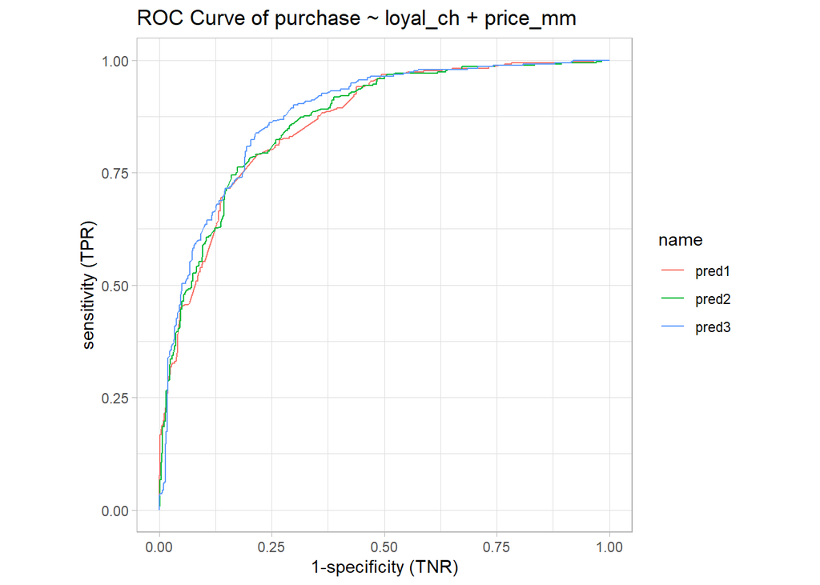

```r
roc_curve <- ggroc(data = list(pred1 = roc_obj_1pred,
                               pred2 = roc_obj_2pred,
                               pred3 = roc_obj_3pred),
                   legacy.axes = TRUE) +
  coord_fixed() +
  labs(title = "ROC Curve of purchase ~ loyal_ch + price_mm",
       x = "1-specificity (TNR)",
       y = "sensitivity (TPR)") +
  theme_light()

roc_curve
```

The ROC curve suggests that the 3-predictor model is better than the single and two-predictor models (i.e. it is closer to the top left corner).

#### AUC

```r
auc(roc_obj_1pred)
```

```
## Area under the curve: 0.8617
```

```r
auc(roc_obj_2pred)
```

```
## Area under the curve: 0.8655
```

```r
auc(roc_obj_3pred)
```

```
## Area under the curve: 0.8787
```

The AUC also backs up the first impressions of the three-predictor model being a better fit to the training data.

#### Gini Coefficient

The Gini coefficient normalises AUC so that a random classifier has value 0, and a perfect classifier has value 1.

Gini = 2 × AUC − 1

with a possible range of values

−1 ≤ Gini ≤ 1

Although, as for AUC, the practical range is

0 ≤ Gini ≤ 1

```r
gini_1pred <-  2 * auc(roc_obj_1pred) - 1
gini_1pred
```

```
## [1] 0.7234097
```

```r
gini_2pred <-  2 * auc(roc_obj_2pred) - 1
gini_2pred
```

```
## [1] 0.7309907
```

```r
gini_3pred <-  2 * auc(roc_obj_3pred) - 1
gini_3pred
```

```
## [1] 0.7573643
```

The Gini coefficient also backs the theory that the three predictor model is a better fit to the training data.

#### Add in the Test Data Set

1. Tidy up the data;

```r
juice_test_trim <- juice_test %>%
  mutate(purchase = if_else(purchase == "MM", as.logical(TRUE), as.logical(FALSE))) %>%
  select(-c(sale_price_mm,
            sale_price_ch,
            price_diff,
            list_price_diff,
            store_id,
            store7))
```

2. Apply the model;

```r
juice_model <- glm(purchase ~ loyal_ch + price_mm + disc_mm,
                   data = juice_test_trim,
                   family = binomial(link = "logit"))

juice_model
```

```
##
## Call:  glm(formula = purchase ~ loyal_ch + price_mm + disc_mm, family = binomial(link = "logit"),
##     data = juice_test_trim)
##
## Coefficients:
## (Intercept)     loyal_ch     price_mm      disc_mm
##       7.307       -8.455       -1.924        3.221
##
## Degrees of Freedom: 213 Total (i.e. Null);  210 Residual
## Null Deviance:       279.6
## Residual Deviance: 131.1     AIC: 139.1
```

3. Add Predictions;

```r
juice_test_with_pred <- juice_test_trim %>%
  add_predictions(juice_3a, type = "response")
head(juice_test_with_pred)
```

| purchase | weekof_purchase | price_ch | price_mm | disc_ch | disc_mm | special_ch | special_mm | loyal_ch | pct_disc_mm | pct_disc_ch | store | pred |
| --- | --- | --- | --- | --- | --- | --- | --- | --- | --- | --- | --- | --- |
| FALSE | 228 | 1.69 | 1.69 | 0.00 | 0.0 | 0 | 0 | 0.956535 | 0.000000 | 0.000000 | 0 | 0.07205392 |
| FALSE | 253 | 1.89 | 2.09 | 0.13 | 0.0 | 0 | 0 | 0.680000 | 0.000000 | 0.068783 | 2 | 0.15805188 |
| TRUE | 247 | 1.99 | 2.23 | 0.00 | 0.0 | 0 | 0 | 0.320000 | 0.000000 | 0.000000 | 3 | 0.54432816 |
| TRUE | 275 | 1.96 | 2.18 | 0.00 | 0.8 | 0 | 1 | 0.000254 | 0.366972 | 0.000000 | 2 | 0.98235378 |
| FALSE | 263 | 1.86 | 2.13 | 0.27 | 0.0 | 0 | 0 | 0.868928 | 0.000000 | 0.145161 | 0 | 0.05452584 |
| TRUE | 229 | 1.79 | 1.79 | 0.00 | 0.0 | 0 | 0 | 0.480000 | 0.000000 | 0.000000 | 3 | 0.51280587 |

4. Check predictions again against threshold = 0.5;

```r
threshold <- 0.5

juice_test_with_pred <- juice_test_with_pred %>%
  mutate(pred_thresh_0.5 = pred >= threshold) %>%
  relocate(pred_thresh_0.5, .after = "purchase")

head(juice_test_with_pred, 10)
```

| purchase | pred_thresh_0.5 | weekof_purchase | price_ch | price_mm | disc_ch | disc_mm | special_ch | special_mm | loyal_ch | pct_disc_mm | pct_disc_ch | store | pred |
| --- | --- | --- | --- | --- | --- | --- | --- | --- | --- | --- | --- | --- | --- |
| FALSE | FALSE | 228 | 1.69 | 1.69 | 0.00 | 0.00 | 0 | 0 | 0.956535 | 0.000000 | 0.000000 | 0 | 0.07205392 |
| FALSE | FALSE | 253 | 1.89 | 2.09 | 0.13 | 0.00 | 0 | 0 | 0.680000 | 0.000000 | 0.068783 | 2 | 0.15805188 |
| TRUE | TRUE | 247 | 1.99 | 2.23 | 0.00 | 0.00 | 0 | 0 | 0.320000 | 0.000000 | 0.000000 | 3 | 0.54432816 |
| TRUE | TRUE | 275 | 1.96 | 2.18 | 0.00 | 0.80 | 0 | 1 | 0.000254 | 0.366972 | 0.000000 | 2 | 0.98235378 |
| FALSE | FALSE | 263 | 1.86 | 2.13 | 0.27 | 0.00 | 0 | 0 | 0.868928 | 0.000000 | 0.145161 | 0 | 0.05452584 |
| TRUE | TRUE | 229 | 1.79 | 1.79 | 0.00 | 0.00 | 0 | 0 | 0.480000 | 0.000000 | 0.000000 | 3 | 0.51280587 |
| TRUE | TRUE | 261 | 1.86 | 2.13 | 0.00 | 0.24 | 0 | 0 | 0.320000 | 0.112676 | 0.000000 | 0 | 0.71606889 |
| FALSE | FALSE | 267 | 1.86 | 2.18 | 0.00 | 0.40 | 0 | 1 | 0.890772 | 0.183486 | 0.000000 | 2 | 0.10577480 |
| FALSE | FALSE | 255 | 1.76 | 2.18 | 0.00 | 0.00 | 0 | 0 | 0.885915 | 0.000000 | 0.000000 | 1 | 0.04545068 |
| FALSE | FALSE | 246 | 1.89 | 2.09 | 0.00 | 0.00 | 0 | 0 | 0.500000 | 0.000000 | 0.000000 | 2 | 0.35011004 |

5. Check Accuracy / Specificity / Sensitivity The performance of the model can be checked with a confusion table;

```r
conf_table <- juice_test_with_pred %>%
  tabyl(purchase, pred_thresh_0.5)

conf_table
```

| purchase | FALSE | TRUE |
| --- | --- | --- |
| FALSE | 129 | 8 |
| TRUE | 11 | 66 |

```r
juice_test_with_pred %>%
  accuracy(as.factor(purchase), as.factor(pred_thresh_0.5))
```

| .metric | .estimator | .estimate |
| --- | --- | --- |
| accuracy | binary | 0.911215 |

```r
juice_test_with_pred %>%
  sensitivity(as.factor(purchase), as.factor(pred_thresh_0.5))
```

| .metric | .estimator | .estimate |
| --- | --- | --- |
| sensitivity | binary | 0.9416058 |

And the specificity (True Negative Rate);

```r
juice_test_with_pred %>%
  specificity(as.factor(purchase), as.factor(pred_thresh_0.5))
```

| .metric | .estimator | .estimate |
| --- | --- | --- |
| specificity | binary | 0.8571429 |

#### Summary

Overall a three-predictor model has been found to be the best model for predicting whether or not a customer might buy Minute Maid or Citrus Hill, according to the relationship;

$$purchase_{(MM\ or\ CH)} \sim CH\_brand\_loyalty + price\_MM + discount\_MM$$